# COMPSCIX 415.2 Homework 5/Midterm

### 5-2)Reproduce this graphic using the diamonds data set.

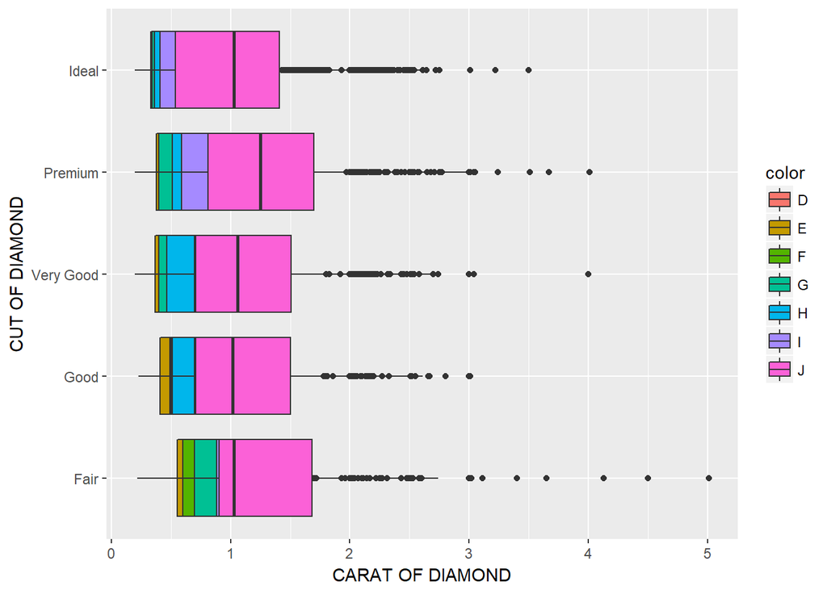

```r
library(ggplot2)
ggplot(data = diamonds) +geom_boxplot(mapping = aes(x = cut, y = carat, fill=color),position="identity") +
xlab('CUT OF DIAMOND') + ylab('CARAT OF DIAMOND') +
coord_flip()
```

### 5-3)The previous graphic is not very useful. We can make it much more useful by changing one thing about it. Make the change and plot it again

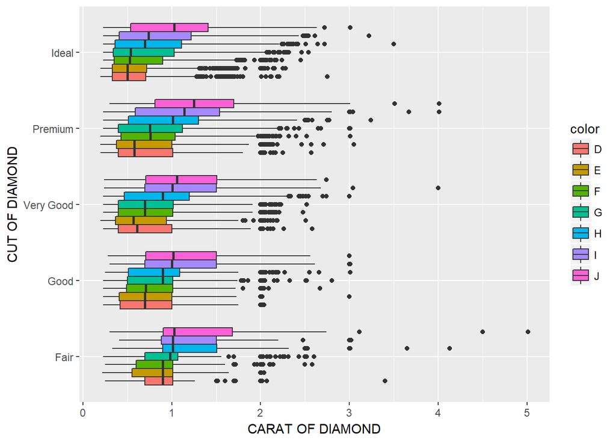

```r
library(ggplot2)
ggplot(data = diamonds) +geom_boxplot(mapping = aes(x = cut, y = carat, fill=color),position="dodge") +
xlab('CUT OF DIAMOND') + ylab('CARAT OF DIAMOND') +
coord_flip()
```

Answer: clearly the first boxplot has stacked the data on top of each other in one boxplot for each cut and we cannot clearly distingiush between various colors. but by taking out position “identity” or converting it to “dodge” we can sepearte box plots for each color for each cut and transparently see thier outliers and median and min and max, while for example we cannot see the outliers for each color in first boxplot.

## 6)Data munging and wrangling (6 points)

### 6-1)Is this data “tidy”? If yes, leave it alone and go to the next problem. If no, make it tidy. Note: this data set is called table2 and is available in the tidyverse package. It should be ready for you to use after you’ve loaded the tidyverse package.

answer:No it is not tidy. In order for one table to be tidy it should meet below criteria that each variable in the data set is placed in its own column and each observation is placed in its own row and each value is placed in its own cell. In this case under type we have both cases and population under one column so we really need to have a column for population and a column for cases for the same information of country, year and count. So we use spread() that returns a copy of your data set but transform two variable under one column to two columns so basically it adds a new column for each unique value. We first use the key column and then value column in the paranthesis. So for table 2 we have:

```r
library(tidyverse)
spread(table2, type, count)
```

```
## # A tibble: 6 x 4
##   country      year  cases population
##   <chr>       <int>  <int>      <int>
## 1 Afghanistan  1999    745   19987071
## 2 Afghanistan  2000   2666   20595360
## 3 Brazil       1999  37737  172006362
## 4 Brazil       2000  80488  174504898
## 5 China        1999 212258 1272915272
## 6 China        2000 213766 1280428583
```

### 6-2)Create a new column in the diamonds data set called price_per_carat that shows the price of each diamond per carat (hint: divide). Only show me the code, not the output.

```r
diamonds <- diamonds%>%mutate(price_per_carat = price/carat)
```

### 6-3)For each cut of diamond in the diamonds data set, how many diamonds, and what proportion, have a price > 10000 and a carat < 1.5? There are several ways to get to an answer, but your solution must use the data wrangling verbs from the tidyverse in order to get credit.

```r
diamondsfair <- select(filter(diamonds, cut == 'Fair'),price,carat)
diamondsfairconditioned <- select(filter(diamonds, price>10000 & carat<1.5,cut == 'Fair'),price,carat)
summarize(diamonds, number_of_diamonds_fair = nrow(diamondsfairconditioned), proportion_percent= (number_of_diamonds_fair/nrow(diamondsfair)*100))
```

```
## # A tibble: 1 x 2
##   number_of_diamonds_fair proportion_percent
##                     <int>              <dbl>
## 1                       4              0.248
```

```r
diamondsGood <- select(filter(diamonds, cut == 'Good'),price,carat)
diamondsGoodconditioned <- select(filter(diamonds, price>10000 & carat<1.5,cut == 'Good'),price,carat)
summarize(diamonds, number_of_diamonds_good = nrow(diamondsGoodconditioned), proportion_percent= (number_of_diamonds_good/nrow(diamondsGood)*100))
```

```
## # A tibble: 1 x 2
##   number_of_diamonds_good proportion_percent
##                     <int>              <dbl>
## 1                      17              0.347
```

```r
diamondsVeryGood <- select(filter(diamonds, cut == 'Very Good'),price,carat)
diamondsVeryGoodconditioned<- select(filter(diamonds, price>10000 & carat<1.5,cut == 'Very Good'),price,carat)
summarize(diamonds, number_of_diamonds_good = nrow(diamondsVeryGoodconditioned), proportion_percent= (number_of_diamonds_good/nrow(diamondsVeryGood)*100))
```

```
## # A tibble: 1 x 2
##   number_of_diamonds_good proportion_percent
##                     <int>              <dbl>
## 1                     155               1.28
```

```r
diamondsPremium <- select(filter(diamonds, cut == 'Premium'),price,carat)
diamondsPremiumconditioned <- select(filter(diamonds, price>10000 & carat<1.5,cut == 'Premium'),price,carat)
summarize(diamonds, number_of_diamonds_Premium = nrow(diamondsPremiumconditioned), proportion_percent= (number_of_diamonds_Premium/nrow(diamondsPremium)*100))
```

```
## # A tibble: 1 x 2
##   number_of_diamonds_Premium proportion_percent
##                        <int>              <dbl>
## 1                        173               1.25
```

```r
diamondsIdeal <- select(filter(diamonds, cut == 'Ideal'),price,carat)
diamondsIdealconditioned <- select(filter(diamonds, price>10000 & carat<1.5,cut == 'Ideal'),price,carat)
summarize(diamonds, number_of_diamonds_Ideal = nrow(diamondsIdealconditioned), proportion_percent= (number_of_diamonds_Ideal/nrow(diamondsIdeal)*100))
```

```
## # A tibble: 1 x 2
##   number_of_diamonds_Ideal proportion_percent
##                      <int>              <dbl>
## 1                      485               2.25
```

per tables above which indiacates number of diamonds and their proportion for each diamond cut we can find out that the more diamonds cut improves from fair and good to premium and ideal, number of diamonds of less than 1.5 carat with price over 10K increases. Also there is a larger proportion of less than 1.5 carat and more than $10K to total number of a one cut, for ideal compare to lower grades diamonds.That being said it is less likely that lower grades cut with less 1.5 carat to be sold over 10K. Also , we find that there is a direct relationship between increase in carat and in increase in price.

#### 6-3-2)Do we need to be wary of any of these numbers? Why?

answer:I am going to be worried about fair and good cut diamonds since there is not that many of them compare to their cut samples. This can be either an error or selling a low grade cut diamond for a high price. I would change it by replacing with ideal or premium for my customer.I also take the summary of each cut catagorry and plot the box plot to see if these are outliers or not and how close they are to the median and the box.

## 7)EDA

### 7-1)During what time period is this data from?

Answer: 2000 to 2015

```r
txhousing %>%
  count(year)
```

```
## # A tibble: 16 x 2
##     year     n
##    <int> <int>
##  1  2000   552
##  2  2001   552
##  3  2002   552
##  4  2003   552
##  5  2004   552
##  6  2005   552
##  7  2006   552
##  8  2007   552
##  9  2008   552
## 10  2009   552
## 11  2010   552
## 12  2011   552
## 13  2012   552
## 14  2013   552
## 15  2014   552
## 16  2015   322
```

### 7-2)How many cities are represented?

answer: 46 cities with 187 data points for each

```r
txhousing %>%
  count(city)
```

```
## # A tibble: 46 x 2
##    city                      n
##    <chr>                 <int>
##  1 Abilene                 187
##  2 Amarillo                187
##  3 Arlington               187
##  4 Austin                  187
##  5 Bay Area                187
##  6 Beaumont                187
##  7 Brazoria County         187
##  8 Brownsville             187
##  9 Bryan-College Station   187
## 10 Collin County           187
## # ... with 36 more rows
```

### 7-3)Which city, month and year had the highest number of sales?

answer: houston,month of July in 2015 has the highest sales.

```r
txhousing[which.max(txhousing$sales),]
```

```
## # A tibble: 1 x 9
##   city     year month sales     volume median listings inventory  date
##   <chr>   <int> <int> <dbl>      <dbl>  <dbl>    <dbl>     <dbl> <dbl>
## 1 Houston  2015     7  8945 2568156780 217600    23875       3.4 2016.
```

### 7-4)What kind of relationship do you think exists between the number of listings and the number of sales? Check your assumption and show your work.

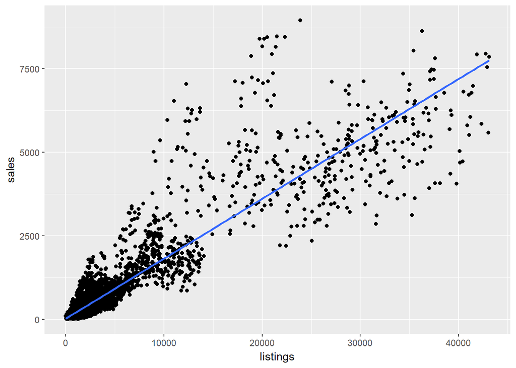

```r
ggplot(txhousing, aes(listings, sales)) +
  geom_point() +
  geom_smooth(method = "lm",se = F)
```

### 7-5)What proportion of sales is missing for each city?

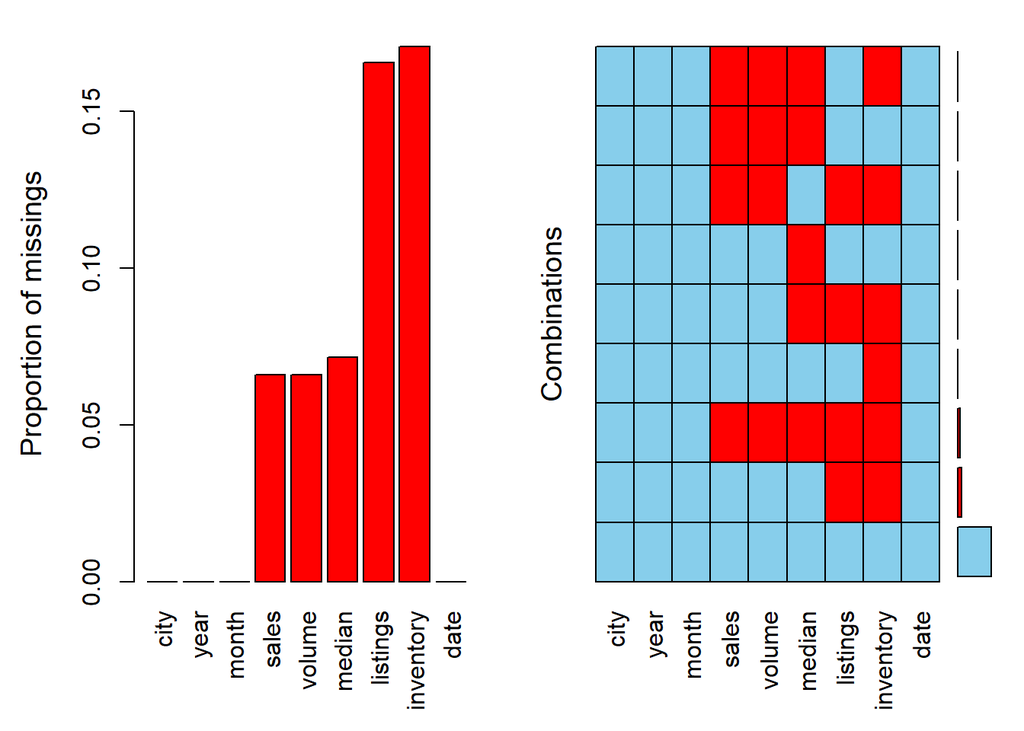

```r
library(VIM)
aggr(txhousing)
```

```r
map_df(txhousing,function(x) sum(is.na(x)))
```

```
## # A tibble: 1 x 9
##    city  year month sales volume median listings inventory  date
##   <int> <int> <int> <int>  <int>  <int>    <int>     <int> <int>
## 1     0     0     0   568    568    616     1424      1467     0
```

```r
sum(is.na(txhousing$sales))
```

```
## [1] 568
```

```r
txhousing %>%
  group_by(city) %>%
  summarise(
    count = n(),
    number_of_NAs = sum(is.na(txhousing$city)))
```

```
## # A tibble: 46 x 3
##    city                  count number_of_NAs
##    <chr>                 <int>         <int>
##  1 Abilene                 187             0
##  2 Amarillo                187             0
##  3 Arlington               187             0
##  4 Austin                  187             0
##  5 Bay Area                187             0
##  6 Beaumont                187             0
##  7 Brazoria County         187             0
##  8 Brownsville             187             0
##  9 Bryan-College Station   187             0
## 10 Collin County           187             0
## # ... with 36 more rows
```

### 7-6)Looking at only the cities and months with greater than 500 sales:

#### 7-6-1)Are the distributions of the median sales price (column name median), when grouped by city, different? The same? Show your work.

Answer: The distribition of median sales price for each city both in boxplot and histogram for all sales is completely different.However, in cities and month that is sales more than 500, both boxplot and histogran indicates some level of consistency although not exactly the same.for example median price for cities of more than 500 sales are mainly ranging between 100K to 225K

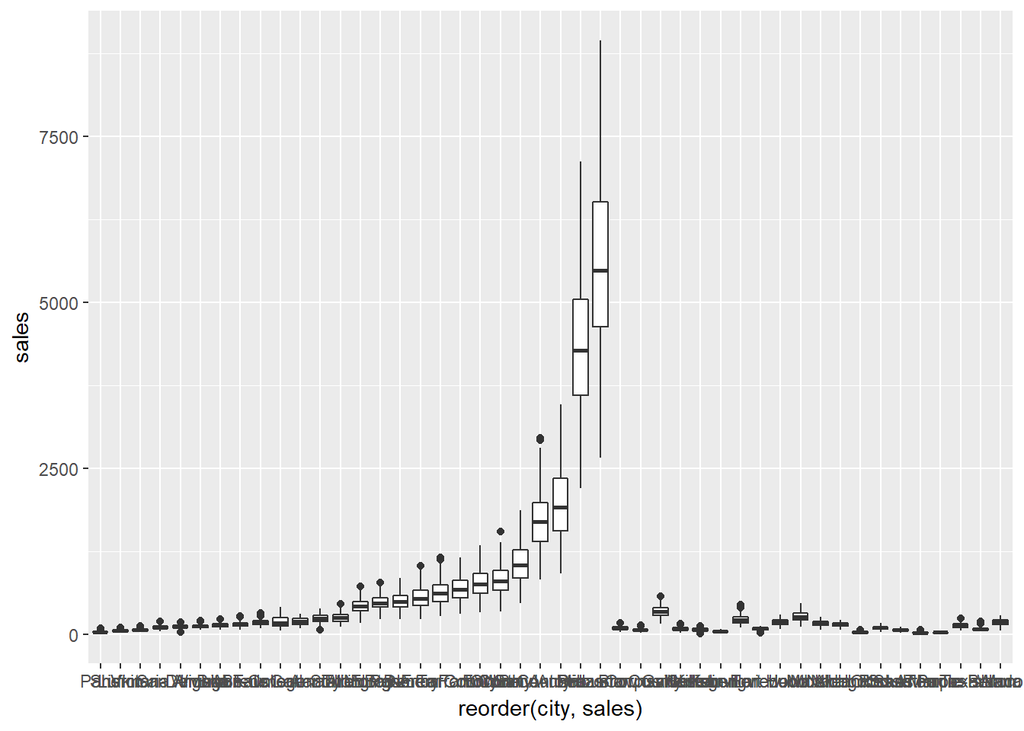

```r
txhousing4<- filter(txhousing, sales>500)
ggplot(data=txhousing)+geom_boxplot(mapping = aes(x=reorder(city,sales),y=sales))
```

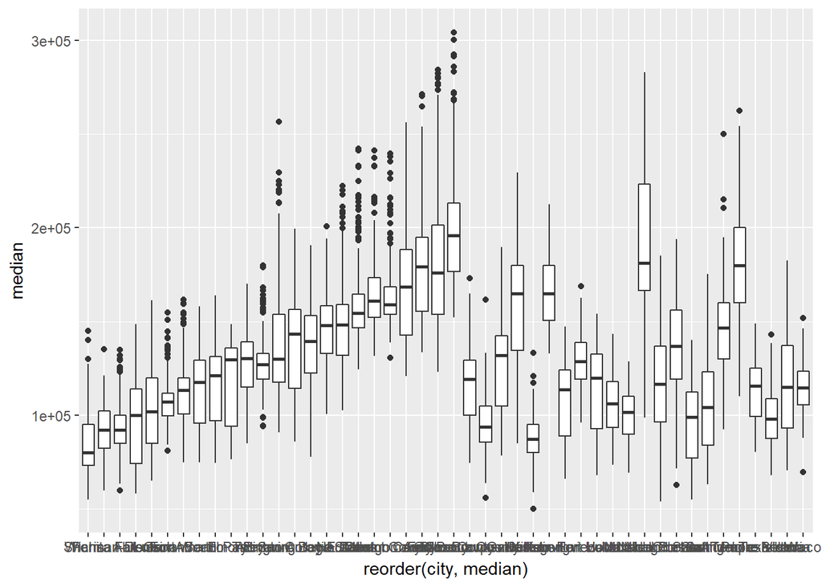

```r
ggplot(data=txhousing)+geom_boxplot(mapping = aes(x=reorder(city,median),y=median))
```

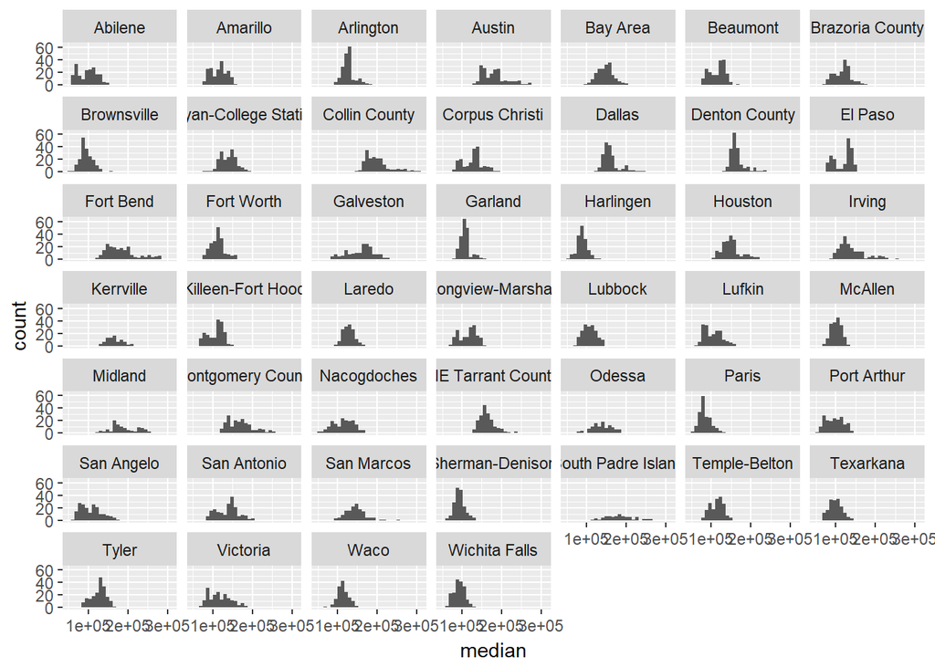

```r
ggplot(data=txhousing)+geom_histogram(mapping = aes(x=median))+facet_wrap(~city)
```

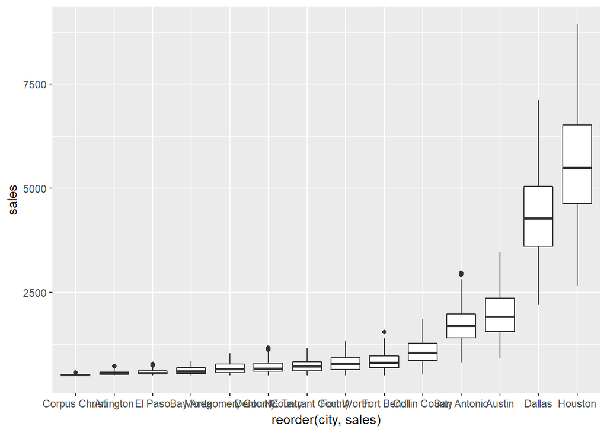

```r
ggplot(data=txhousing4)+geom_boxplot(mapping = aes(x=reorder(city,sales),y=sales))
```

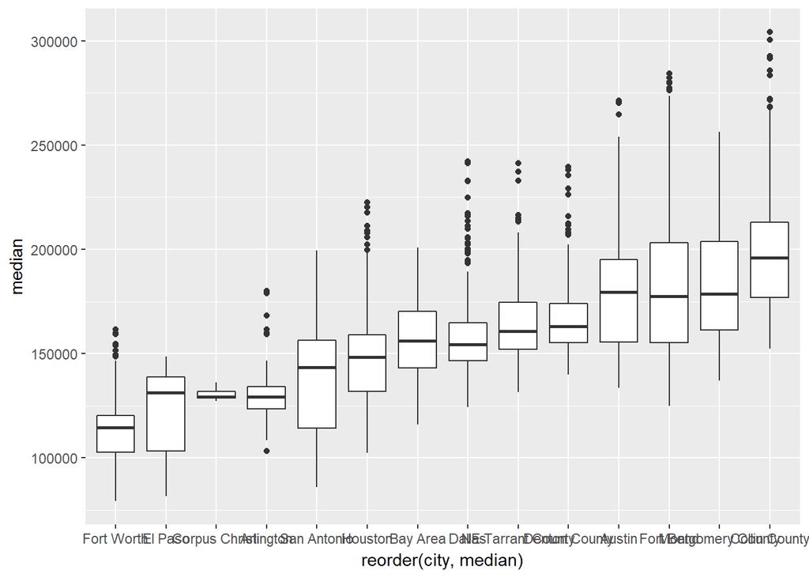

```r
ggplot(data=txhousing4)+geom_boxplot(mapping = aes(x=reorder(city,median),y=median))
```

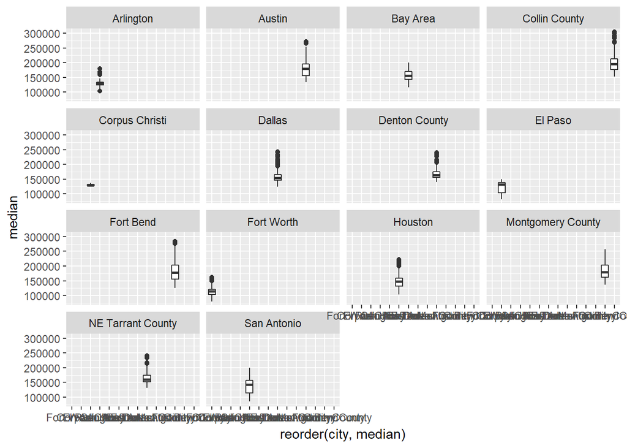

```r
ggplot(data=txhousing4)+geom_boxplot(mapping = aes(x=reorder(city,median),y=median))+facet_wrap(~city)
```

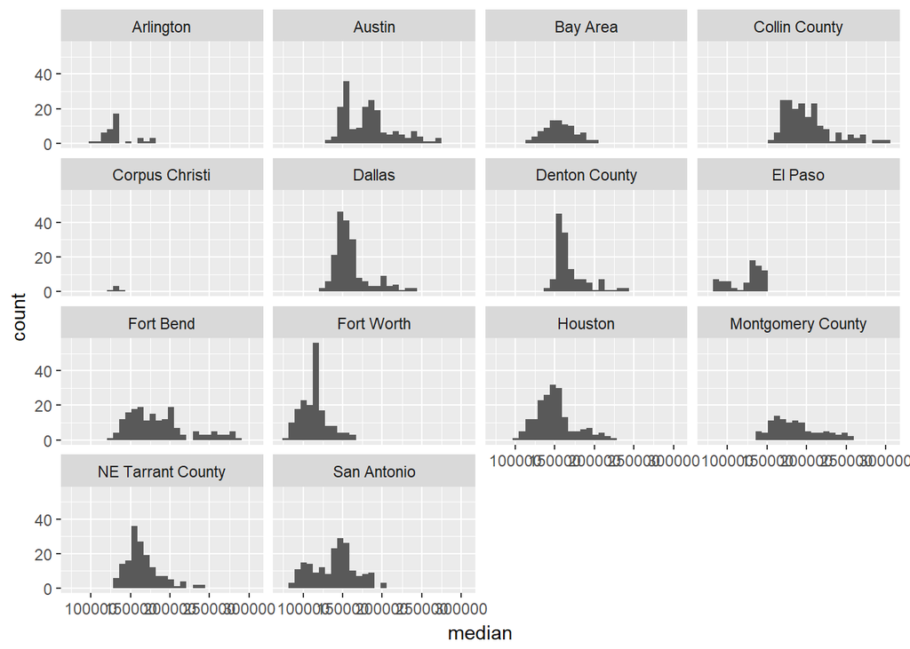

```r
ggplot(data=txhousing4)+geom_histogram(mapping = aes(x=median))+facet_wrap(~city)
```

#### 7-6-2)Any cities that stand out that you’d want to investigate further?

answer: for more than 500 sales , cities like corpus christi has a limited amount of sales data and lower median price which makes it interesting case to know why. same for arlington and el paso.

#### 7-6-3)Why might we want to filter out all cities and months with sales less than 500?

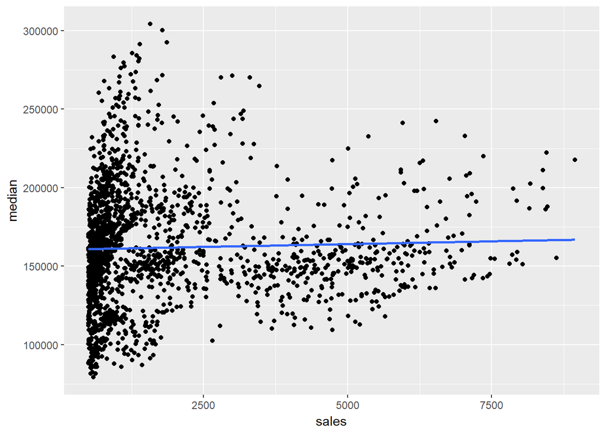

```r
ggplot(txhousing4, aes(sales, median)) + geom_point() +geom_smooth(method = "lm",se = F)
```

answer:There is values with infinite values for less than 500 sales and also looks like there is a lot of noise for cities with less than 500 sales when we plot the box plot for sales and median for txhousing vs txhousing 4 ( for more than 500 sales). When I used re-order function for less than 500 sales , plots could not be re-ordered 100% while for more than 500 sales both sale and median price were reordered without any missing or infinite data. so it seems that there are values in less than 500 sales that make our analysis prone to error. Also , cities for more than 500 sales can give us a more better median price for purchase certainty and they are more recent , it gives a more confident number now that it is fully re-ordered and there is no error message for infinite values in rows as well.

The End